# ipynb-slideshow slides

## Custom cell metadata in Jupyter notebooks via org-mode

One feature of Jupyter notebooks that is sometimes used is custom cell metadata. This can, for example be used to put names on a cell, or tags for future analysis or conversion. One of the main uses is for annotating cells as part of a slide show. A cell can be a slide, subslide, fragment, note or skip.

ox-ipynb mostly supports this now. You can add metadata to a heading via properties or paragraphs via an attr_ipynb line or to a code block. The syntax is lispy, basically cons and list cells. These are read by emacs-lisp and converted to json at export time. Here is an example:

```python
for i in range(5):
    print(i)
```

```
# Out[2]:
# output
0
1
2
3
4
```

You can also use it to put a name and list of tags on a markdown cell.

For convenience you can call `ox-ipynb-insert-slide` to insert the metadata on a paragraph or src-block. It will offer completion on the types of slides you can insert. This is a subslide.

These features were requested in these issues:

https://github.com/jkitchin/ox-ipynb/issues/6

https://github.com/jkitchin/ox-ipynb/issues/11

### Export as slide show

There is a new export option `ox-ipynb-export-to-ipynb-slides-and-open`

#### Or if you like keybindings

C-c C-e n s.

*This was a slide fragment.*

### You can have equations in your slides

A spiral is a parametric plot in $t$:

$x = \cos(t) e^{-a t}$

and

$y = \sin(t) e^{-a t}$

### You can put in code and figures in your slides

```
# Out[2]:
# text/plain



# image/png
```

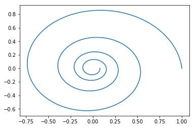

```python
import numpy as np
t = np.linspace(0, 8 * np.pi, 500)
x = np.cos(t) * np.exp(-0.1 * t)
y = np.sin(t) * np.exp(-0.1 * t)

%matplotlib inline
import matplotlib.pyplot as plt
plt.plot(x, y)
```

## Not bad for something quick and easy!

See https://github.com/jkitchin/ox-ipynb.

Probably there are issues. Report them at https://github.com/jkitchin/ox-ipynb/issues